# Movement_Activity_Analysis

Qi

Sunday, May 17, 2015

# Personal Movement Activity Analysis

It is now possible to collect a large amount of data about personal movement using activity monitoring devices such as a Fitbit, Nike Fuelband, or Jawbone Up. These type of devices are part of the “quantified self” movement - a group of enthusiasts who take measurements about themselves regularly to improve their health, to find patterns in their behavior, or because they are tech geeks. But these data remain under-utilized both because the raw data are hard to obtain and there is a lack of statistical methods and software for processing and interpreting the data.

This assignment makes use of data from a personal activity monitoring device. This device collects data at 5 minute intervals through out the day. The data consists of two months of data from an anonymous individual collected during the months of October and November, 2012 and include the number of steps taken in 5 minute intervals each day.

## 1. Loading and preprocessing the data.

1.1. Load the data

```r
# read the data
activity_data <- read.csv("./data/activity.csv", header = TRUE, sep = ",", na.strings = "NA")
# show some sample data
head(activity_data)
```

```
##   steps      date interval
## 1    NA 10/1/2012        0
## 2    NA 10/1/2012        5
## 3    NA 10/1/2012       10
## 4    NA 10/1/2012       15
## 5    NA 10/1/2012       20
## 6    NA 10/1/2012       25
```

1.2. Process/transform the data

```r
# check which field has missing values
sum(is.na(activity_data$steps))
```

```
## [1] 2304
```

```r
# check which field has missing values
sum(is.na(activity_data$date))
```

```
## [1] 0
```

```r
# check which field has missing values
sum(is.na(activity_data$interval))
```

```
## [1] 0
```

```r
# convert each field to the right format
activity_data$steps <- as.numeric(activity_data$steps)
activity_data$date <- as.Date(activity_data$date, format = "%m/%d/%Y")
activity_data$interval <- as.factor(activity_data$interval)
# filter out the records with missing values
activity_data_no_na <- activity_data[!is.na(activity_data$steps), ]
# show some sample data
head(activity_data_no_na)
```

```
##     steps       date interval
## 289     0 2012-10-02        0
## 290     0 2012-10-02        5
## 291     0 2012-10-02       10
## 292     0 2012-10-02       15
## 293     0 2012-10-02       20
## 294     0 2012-10-02       25
```

## 2. What is mean total number of steps taken per day?

2.1. The total number of steps per day

```r
# count the number steps per day
steps_per_day <- aggregate(steps ~ date, data = activity_data_no_na, sum)
colnames(steps_per_day) <- c("date", "steps")
steps_per_day$steps <- as.numeric(steps_per_day$steps)
# show some sample data
head(steps_per_day)
```

```
##         date steps
## 1 2012-10-02   126
## 2 2012-10-03 11352
## 3 2012-10-04 12116
## 4 2012-10-05 13294
## 5 2012-10-06 15420
## 6 2012-10-07 11015
```

2.2. Histogram of the total number of steps taken each day

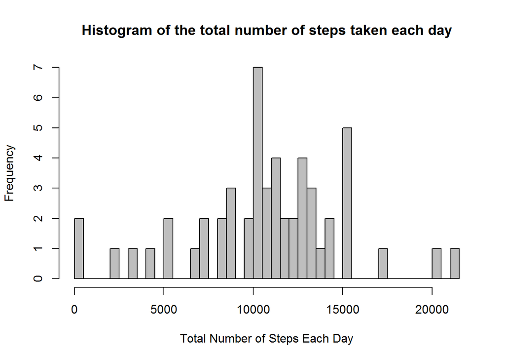

```r
hist(steps_per_day$steps, xlab = "Total Number of Steps Each Day", main = "Histogram of the total number of steps taken each day", breaks = 50, col = "grey")
```

2.3. Mean and median of the total number of steps taken per day

```r
# calculate the mean
mean(steps_per_day$steps)
```

```
## [1] 10766.19
```

```r
# calculate the median
median(steps_per_day$steps)
```

```
## [1] 10765
```

## 3. What is the average daily activity pattern?

3.1. The average number of steps taken, averaged across all days (y-axis)

```r
# calculate he avergae number of steps per day
avg_steps_per_interval <- aggregate(activity_data_no_na$steps, by = list(interval=activity_data_no_na$interval), FUN = mean)
colnames(avg_steps_per_interval) <- c("interval", "average_steps")
# show some sample data
head(avg_steps_per_interval)
```

```
##   interval average_steps
## 1        0     1.7169811
## 2        5     0.3396226
## 3       10     0.1320755
## 4       15     0.1509434
## 5       20     0.0754717
## 6       25     2.0943396
```

3.2. Time series plot of the average number of steps taken per interval

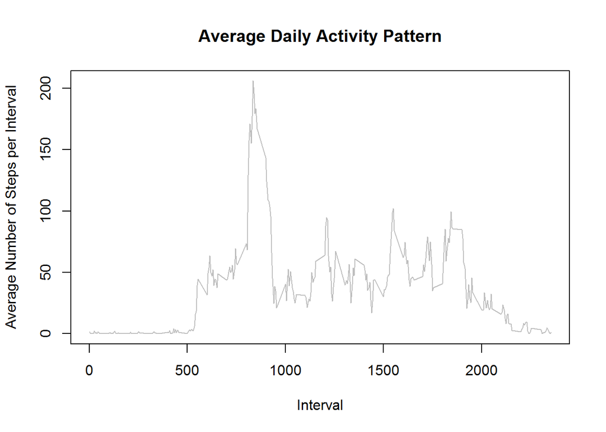

```r
plot(as.integer(levels(avg_steps_per_interval$interval)), avg_steps_per_interval$average_steps, xlab = "Interval", ylab = "Average Number of Steps per Interval", main = "Average Daily Activity Pattern", type="l", col ="grey")
```

3.3. The maximum average number of the steps in the 5-minute interval

```r
# find the max number of steps in the intervals
max_steps <- max(avg_steps_per_interval$average_steps)
max_steps
```

```
## [1] 206.1698
```

```r
# find the intervals with the max number of steps
max_steps_interval <- avg_steps_per_interval[which.max(avg_steps_per_interval$average_steps), ]$interval
max_steps_interval
```

```
## [1] 835
## 288 Levels: 0 5 10 15 20 25 30 35 40 45 50 55 100 105 110 115 120 ... 2355
```

## 4. Imputing missing values

4.1. The total number of missing values in the dataset

```r
# check which field has missing values
sum(is.na(activity_data$steps))
```

```
## [1] 2304
```

```r
# check which field has missing values
sum(is.na(activity_data$date))
```

```
## [1] 0
```

```r
# check which field has missing values
sum(is.na(activity_data$interval))
```

```
## [1] 0
```

4.2. Create a duplicate dataset by filling in all of the missing values in the dataset by the mean of that 5-minute interval

```r
# find the records with missing values
na_index <- which(is.na(as.character(activity_data$steps)))
activity_data_na_filled <- activity_data
# fill the missing values with the mean of the 5-minute interval
activity_data_na_filled[na_index, ]$steps <- unlist(lapply(na_index, FUN=function(na_index){avg_steps_per_interval[activity_data[na_index, ]$interval  ==avg_steps_per_interval$interval, ]$average_steps}))
# show the summary of the filled data
str(activity_data_na_filled)
```

```
## 'data.frame':    17568 obs. of  3 variables:
##  $ steps   : num  1.717 0.3396 0.1321 0.1509 0.0755 ...
##  $ date    : Date, format: "2012-10-01" "2012-10-01" ...
##  $ interval: Factor w/ 288 levels "0","5","10","15",..: 1 2 3 4 5 6 7 8 9 10 ...
```

4.3. Histogram of the total number of steps taken each day

```r
# count the number steps per day in the imputed dataset
steps_each_day_filled <- aggregate(steps ~ date, data = activity_data_na_filled, sum)
colnames(steps_each_day_filled) <- c("date", "steps")
# show some sample data
head(steps_each_day_filled)
```

```
##         date    steps
## 1 2012-10-01 10766.19
## 2 2012-10-02   126.00
## 3 2012-10-03 11352.00
## 4 2012-10-04 12116.00
## 5 2012-10-05 13294.00
## 6 2012-10-06 15420.00
```

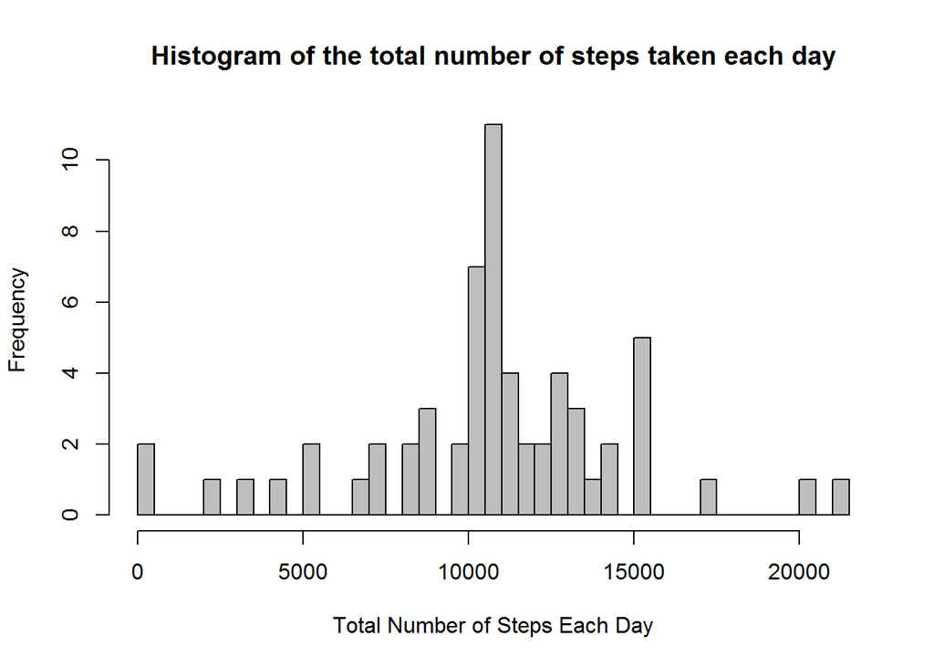

```r
hist(as.numeric(steps_each_day_filled$steps), xlab = "Total Number of Steps Each Day", main = "Histogram of the total number of steps taken each day", breaks = 50, col = "grey")
```

4.4. The mean and median total number of steps taken per day for the imputed dataset

```r
# calculate the mean in the imputed dataset
mean(steps_each_day_filled$steps)
```

```
## [1] 10766.19
```

```r
# calculate the median in the imputed dataset
median(steps_each_day_filled$steps)
```

```
## [1] 10766.19
```

Conclusion: After imputing, mean is the same, while median only increased 1.19. Imputation almost has no effect on the estimates of the total daily number of steps.

## 5. Are there differences in activity patterns between weekdays and weekends?

5.1. Dataset with two levels - “weekday” and “weekend” indicating whether a given date is a weekday or weekend day

```r
# classify the records into weekdays and weekends
activity_data_na_filled$day <- as.factor(weekdays(activity_data_na_filled$date))
activity_data_na_filled$is_weekday <- ifelse(!(activity_data_na_filled$day %in% c("Saturday","Sunday")), TRUE, FALSE)
# calculate he avergae number of steps per weekday
weekdays_data <- activity_data_na_filled[activity_data_na_filled$is_weekday, ]
avg_steps_per_interval_weekdays <- aggregate(weekdays_data$steps, by=list(interval=weekdays_data$interval), FUN=mean)
# calculate he avergae number of steps per weekend
weekends_data <- activity_data_na_filled[!activity_data_na_filled$is_weekday, ]
avg_steps_per_interval_weekends <- aggregate(weekends_data$steps, by=list(interval=weekends_data$interval), FUN=mean)
# add the column names for the weekday and weekend datasets
colnames(avg_steps_per_interval_weekdays) <- c("interval", "avg_steps")
colnames(avg_steps_per_interval_weekends) <- c("interval", "avg_steps")
# add a column to identify the weekday and weekend records
avg_steps_per_interval_weekdays$day <- "Weekday"
avg_steps_per_interval_weekends$day <- "Weekend"
# merge weekday and weekend datasets
week_data <- rbind(avg_steps_per_interval_weekdays, avg_steps_per_interval_weekends)
week_data$day <- as.factor(week_data$day)
# show some sample data
head(week_data)
```

```
##   interval  avg_steps     day
## 1        0 2.25115304 Weekday
## 2        5 0.44528302 Weekday
## 3       10 0.17316562 Weekday
## 4       15 0.19790356 Weekday
## 5       20 0.09895178 Weekday
## 6       25 1.59035639 Weekday
```

5.2. Time series plot of the average number of steps taken per interval for weekday and weekend using imputed data.

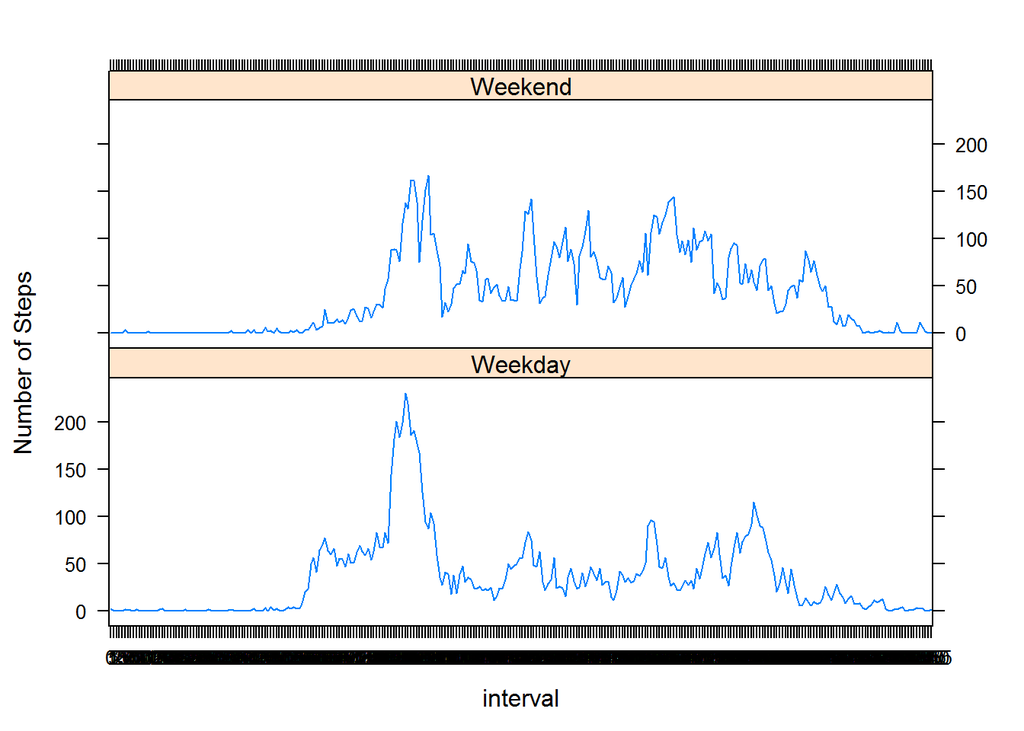

```r
library(lattice)
xyplot(avg_steps ~ interval | day, data = week_data, ylab="Number of Steps", layout = c(1,2), type ="l")
```

In general, the trends of the average number of steps on weekdays and weekends are similar. However, the weekend steps have a higher magnitude and a lower spike compared to the weekday steps.